# Indicators of Loan Default

## by Lucrezia Morvilli

## Investigation Overview

With this presentation, we want to investigate the factors that could be used as good indicators in order to identify the loans that are more likely to default or get charged off.

## Dataset Overview

I have decided to analyse Prosper Loan Data. It includes data on 100k+ loans, with extensive information and various details about them. My focus has been on mainly 12 features among the set of available ones.

## Exploring the variables of interest

Looking at the full dataset, I found out that there is almost a 50-50 split between homeowners and non-homeowners. The visualisations below will show some insights on other variables, namely Term, Duration, Loan Status and Credit Rating.

```
More than 3/4 of the loans have a contractual length of 3 years.
```

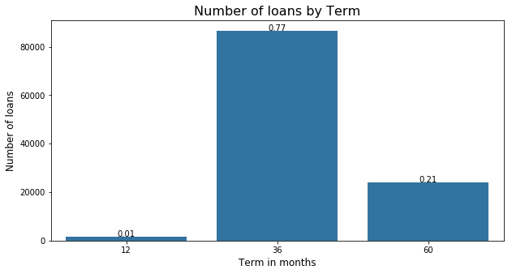

```python
print('More than 3/4 of the loans have a contractual length of 3 years.')
fig = plt.figure(figsize = (10,5))
total = df_loans.shape[0]
base = sb.color_palette()[0]
ax_term = sb.countplot(data = df_loans, x = 'Term', color = base)
for p in ax_term.patches:
    height = p.get_height()
    ax_term.text(p.get_x()+p.get_width()/2.,
            height + 3,
            '{:1.2f}'.format(height/total),
            ha="center")
plt.title('Number of loans by Term', size = 16)
plt.xlabel('Term in months', size = 12)
plt.ylabel('Number of loans', size = 12)
plt.show();
```

```
Loan duration in months was calculated by taking the difference between
closed and creation date. The histogram below shows a bimodal distribution,
with peaks at 1 year and 3 years.
```

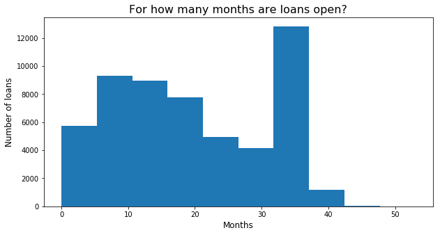

```python
print('Loan duration in months was calculated by taking the difference between \nclosed and creation date. The histogram below shows a bimodal distribution, \nwith peaks at 1 year and 3 years.')
fig = plt.figure(figsize = (10,5))
plt.hist(data = df_loans, x = 'months')
plt.title('For how many months are loans open?', size = 16)
plt.xlabel('Months', size = 12)
plt.ylabel('Number of loans', size = 12);
```

```
The plot includes the proportion over the full dataset and we can see that
49% are current or active loans, whereas 34% are completed. Later on we will focus on the charged off and defaulted loans, which represent 11% and 4% of the dataset respectively.
```

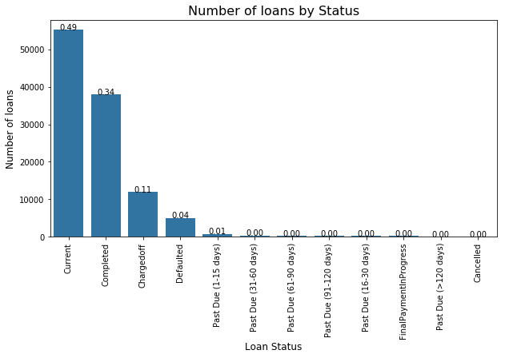

```python
print('The plot includes the proportion over the full dataset and we can see that \n49% are current or active loans, whereas 34% are completed. Later on we will focus on the charged off and defaulted loans, which represent 11% and 4% of the dataset respectively.')
order_status = df_loans.LoanStatus.value_counts().index.tolist()

fig = plt.figure(figsize = (10,5))

ax = sb.countplot(data = df_loans, x = 'LoanStatus', color = base, order = order_status)
plt.xticks(rotation=90)

for p in ax.patches:
    height = p.get_height()
    ax.text(p.get_x()+p.get_width()/2.,
            height + 3,
            '{:1.2f}'.format(height/total),
            ha="center")
plt.title('Number of loans by Status', size = 16)
plt.xlabel('Loan Status', size = 12)
plt.ylabel('Number of loans', size=12)
plt.show();
```

```
Credit Grade and Prosper Rating are similar measures of credit risk, the
former valid before 2009 and the latter post 2009. Both show a normal-like
distribution, with higher counts in the middle ranges.
```

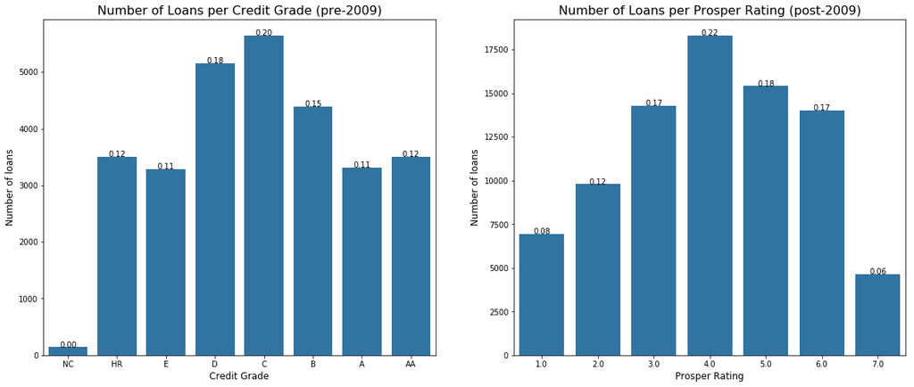

```python
print('Credit Grade and Prosper Rating are similar measures of credit risk, the \nformer valid before 2009 and the latter post 2009. Both show a normal-like \ndistribution, with higher counts in the middle ranges.')

order_credit = ['NC', 'HR', 'E', 'D', 'C', 'B', 'A', 'AA']
total_credit = df_loans.CreditGrade.notnull().sum()
total_rating = df_loans['ProsperRating (numeric)'].notnull().sum()

fig = plt.figure(figsize = (20,8))
plt.subplot(1, 2, 1)

ax_credit = sb.countplot(data = df_loans, x = 'CreditGrade', color = base, order = order_credit)
plt.ylabel('Number of loans', size = 12)
plt.xlabel('Credit Grade', size = 12)
plt.title('Number of Loans per Credit Grade (pre-2009)', size = 16)
for p in ax_credit.patches:
    height = p.get_height()
    ax_credit.text(p.get_x()+p.get_width()/2.,
            height + 3,
            '{:1.2f}'.format(height/total_credit),
            ha="center")

plt.subplot(1,2,2)
ax_rating = sb.countplot(data = df_loans, x = 'ProsperRating (numeric)', color = base)

for p in ax_rating.patches:
    height = p.get_height()
    ax_rating.text(p.get_x()+p.get_width()/2.,
            height + 3,
            '{:1.2f}'.format(height/total_rating),
            ha="center")
plt.ylabel('Number of loans', size = 12)
plt.xlabel('Prosper Rating', size = 12)
plt.title('Number of Loans per Prosper Rating (post-2009)', size = 16)
plt.show();
```

```
Consideration on Prosper Score:

Prosper Score is a credit risk measure analogous to the previous ones. This was introduced in 2009 (as Prosper Rating) and shows a normal-like
distribution as the previous two variables. Moreover, it is highly
correlated with Prosper Rating as shown in the plot on the right.
```

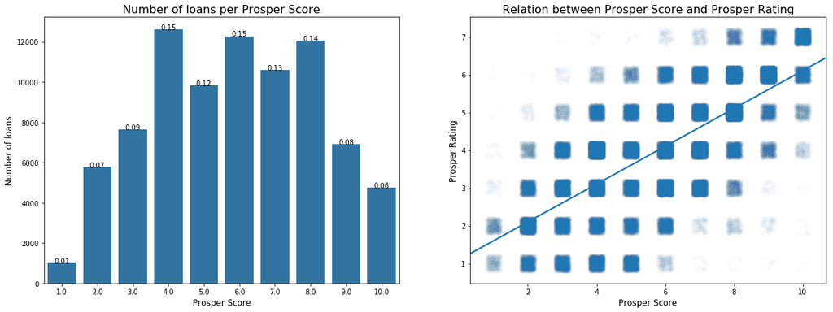

```python
print('Consideration on Prosper Score:\n')
print('Prosper Score is a credit risk measure analogous to the previous ones. This was introduced in 2009 (as Prosper Rating) and shows a normal-like \ndistribution as the previous two variables. Moreover, it is highly \ncorrelated with Prosper Rating as shown in the plot on the right.')

fig = plt.figure(figsize = (20,7))
plt.subplot(1, 2, 1)
total_grade = df_loans['ProsperScore'].notnull().sum()
ax_grade = sb.countplot(data = df_loans, x = 'ProsperScore', color = base)
plt.title('Number of loans per Prosper Score', size = 16)
plt.ylabel('Number of loans', size = 12)
plt.xlabel('Prosper Score', size = 12)

for p in ax_grade.patches:
    height = p.get_height()
    ax_grade.text(p.get_x()+p.get_width()/2.,
            height + 3,
            '{:1.2f}'.format(height/total_grade),
            ha="center")

plt.subplot(1,2,2)
df_prosperRating = df_loans[df_loans['ProsperRating (numeric)'].notnull()]
df_score_rating = df_prosperRating[df_prosperRating.ProsperScore.notnull()]
sb.regplot(data = df_score_rating, x = 'ProsperScore', y = 'ProsperRating (numeric)', x_jitter = 0.2, y_jitter = 0.2, scatter_kws = {'alpha' : 1/100});
plt.title('Relation between Prosper Score and Prosper Rating', size = 16)
plt.xlabel('Prosper Score', size = 12)
plt.ylabel('Prosper Rating', size = 12)
plt.show()
```

## Bivariate Relations

Here, we want to look at the relations between the variables looked at earlier, namely:

- Loan Status vs Rating
- Homeowner vs Rating
- Duration vs Term
- Duration vs Loan Status
- Term vs Loan Status

```
Loan Status vs Rating:

From the plot on the left we can see that more than 30% of the High Risk
loans got charged off (pre-2009) whereas the plot on the right shows that
17.5% of the loans with Prosper Rating equal to 1 were written off
(post-2009). Overall we can see that the higher the credit rating, the lower the chance that loans get written off or default.
```

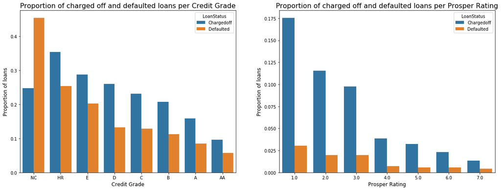

```python
print('Loan Status vs Rating:\n')
print('From the plot on the left we can see that more than 30% of the High Risk \nloans got charged off (pre-2009) whereas the plot on the right shows that \n17.5% of the loans with Prosper Rating equal to 1 were written off \n(post-2009). Overall we can see that the higher the credit rating, the lower the chance that loans get written off or default.')

df_creditGrade = df_loans[df_loans.CreditGrade.notnull()]
df_creditGrade = df_creditGrade[df_creditGrade.LoanStatus.notnull()]

#store totals per Credit Grade and Loan Status
df_grade_status = pd.DataFrame(df_creditGrade.groupby(['CreditGrade', 'LoanStatus'])['ListingNumber'].count()).reset_index()

#store totals per Credit Grade
df_grade_aggregate = pd.DataFrame(df_grade_status.groupby('CreditGrade')['ListingNumber'].sum())

#merge
df_grade_status = df_grade_status.merge(df_grade_aggregate, on = 'CreditGrade', how = 'left')

#get proportions
df_grade_status['Proportion'] = df_grade_status['ListingNumber_x']/df_grade_status['ListingNumber_y']

#for visual
df_grade_status_visual = df_grade_status[df_grade_status['LoanStatus'].isin(['Chargedoff', 'Defaulted'])]

fig = plt.figure(figsize = (20,7))
plt.subplot(1, 2, 1)
order_creditGrade = ['NC', 'HR', 'E', 'D', 'C', 'B', 'A', 'AA']

sb.barplot(data = df_grade_status_visual, x = 'CreditGrade', y = 'Proportion', hue = 'LoanStatus', order = order_creditGrade)
plt.title('Proportion of charged off and defaulted loans per Credit Grade', size = 16)
plt.xlabel('Credit Grade', size = 12)
plt.ylabel('Proportion of loans', size = 12)

df_prosperRating = df_loans[df_loans['ProsperRating (numeric)'].notnull()]
df_prosperRating = df_prosperRating[df_prosperRating.LoanStatus.notnull()]

#store totals per Prosper Rating and Loan Status
df_rating_status = pd.DataFrame(df_prosperRating.groupby(['ProsperRating (numeric)', 'LoanStatus'])['ListingNumber'].count()).reset_index()

#store totals per Prosper Rating
df_rating_aggregate = pd.DataFrame(df_rating_status.groupby('ProsperRating (numeric)')['ListingNumber'].sum())

#merge
df_rating_status = df_rating_status.merge(df_rating_aggregate, on = 'ProsperRating (numeric)', how = 'left')

#get proportions
df_rating_status['Proportion'] = df_rating_status['ListingNumber_x']/df_rating_status['ListingNumber_y']

#for visual
df_rating_status_visual = df_rating_status[df_rating_status['LoanStatus'].isin(['Chargedoff', 'Defaulted'])]
plt.subplot(1, 2, 2)
sb.barplot(data = df_rating_status_visual, x = 'ProsperRating (numeric)', y = 'Proportion', hue = 'LoanStatus')
plt.xlabel('Prosper Rating', size = 12)
plt.title('Proportion of charged off and defaulted loans per Prosper Rating', size = 16)
plt.ylabel('Proportion of loans', size = 12);
```

```
Homeowner Status vs Rating:

We can see a peak of homeowners in the centre, where rating is AA/A or 6/7, decreasing with lower credit ratings. The opposite trend can be observed for non-homeowners. Also, while in the full dataset we have that 49.8% of the
borrowers are not homeowners, when we look at the population of charged off
and defaulted loans, 55.3% do not own a house, indicating there might be
some correlation between these two variables.
```

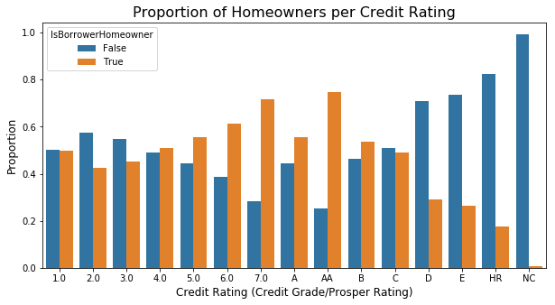

```python
print('Homeowner Status vs Rating:\n')
print('We can see a peak of homeowners in the centre, where rating is AA/A or 6/7, decreasing with lower credit ratings. The opposite trend can be observed for non-homeowners. Also, while in the full dataset we have that 49.8% of the \nborrowers are not homeowners, when we look at the population of charged off \nand defaulted loans, 55.3% do not own a house, indicating there might be \nsome correlation between these two variables.  ')

df_loans['Rating'] = ''

m1 = df_loans['CreditGrade'].notnull()
m2 = df_loans['ProsperRating (numeric)'].notnull()

df_loans['Rating'] = df_loans['Rating'].mask(m1, df_loans['CreditGrade']).mask(m2, df_loans['ProsperRating (numeric)'])

#store totals per Rating and Homeowner status
df_rating_home = pd.DataFrame(df_loans.groupby(['Rating', 'IsBorrowerHomeowner'])['ListingNumber'].count()).reset_index()

#store totals per Rating
df_home_aggregate = pd.DataFrame(df_rating_home.groupby('Rating')['ListingNumber'].sum())

#merge
df_rating_home = df_rating_home.merge(df_home_aggregate, on = 'Rating', how = 'left')

#get proportions
df_rating_home['Proportion'] = df_rating_home['ListingNumber_x']/df_rating_home['ListingNumber_y']

fig = plt.figure(figsize = (10,5))
sb.barplot(data = df_rating_home, x = 'Rating', y = 'Proportion', hue = 'IsBorrowerHomeowner')
plt.title('Proportion of Homeowners per Credit Rating', size = 16)
plt.xlabel('Credit Rating (Credit Grade/Prosper Rating)', size = 12)
plt.ylabel('Proportion', size = 12);
```